# Introduction

Human development is about focusing on the diverse aspects of human life. It is not only about the economic growth of human society but also the societal condition, opportunities, and choice human have and the progress they have made.

```r
head(HDI)
```

| State | Region | Division | HDI | HDI_M | HDI_F | LE | LE_M | LE_F | Earnings | ⋯ | MinWage | pctPOVERTY | pctCHLDPOVERTY | UR | pctMNGMT | pctSERVICE | pctSALESOFFICE | pctFARMFISH | pctCONSTRMAINT | pctPRODTRANSP |
| --- | --- | --- | --- | --- | --- | --- | --- | --- | --- | --- | --- | --- | --- | --- | --- | --- | --- | --- | --- | --- |
| Alabama | South | EastSouthAtlntc | 4.04 | 4.04 | 4.04 | 75.4 | 72.59 | 78.2 | 25530 | ⋯ | <c9> | 19.0 | 27.7 | 5.9 | 30.8 | 15.5 | 26.1 | 0.6 | 10.8 | 16.1 |
| Alaska | West | Pacific | 5.06 | 5.29 | 5.07 | 78.3 | 76.34 | 80.4 | 32140 | ⋯ | 7.8 | 9.9 | 12.9 | 6.2 | 34.1 | 16.3 | 25.2 | 0.9 | 12.7 | 10.8 |
| Arizona | West | Mountain | 4.89 | 4.80 | 4.97 | 79.6 | 77.17 | 82.1 | 27813 | ⋯ | 7.3 | 17.4 | 24.4 | 7.8 | 32.9 | 19.1 | 27.2 | 0.4 | 11.2 | 9.1 |
| Arkansas | South | WestSouthAtlntc | 3.91 | 3.95 | 3.96 | 76.0 | 73.13 | 78.8 | 23992 | ⋯ | 6.3 | 18.8 | 27.6 | 6.9 | 29.4 | 16.3 | 25.9 | 1.1 | 9.8 | 17.5 |
| California | West | Pacific | 5.40 | 5.27 | 5.39 | 80.8 | 78.33 | 83.1 | 30356 | ⋯ | 8.0 | 15.8 | 22.0 | 8.5 | 35.8 | 17.7 | 25.3 | 1.4 | 8.6 | 11.2 |
| Colorado | West | Mountain | 5.53 | 5.55 | 5.45 | 80.0 | 77.79 | 82.2 | 30440 | ⋯ | 7.2 | 13.4 | 17.4 | 6.8 | 38.1 | 16.4 | 24.8 | 0.5 | 10.8 | 9.4 |

# Methods

For the variables, we did four pair. For all four sets of data, we each did one scatter plot, one scatter plot with trend line, two box- plots for each variable and two histograms for each variable. We did scatterplot to see the relationship between the two variables, and the trend line helps us to see the relationship more clearly and identify if it is a strong or weak relationship. We did box-plots because it can help us to see the range, the median of the data and since it is separated by a categorical variable, we can discover the relationship between the continuous variable and the categorical variable. We did the histogram because it allows us to see the maximum and minimum for each variable.

# First variable

The first pair is the male earnings and female earnings. We collected the data from the HDI dataset. The data could be conducted through surveys, social research or statistic report from authentic companies. This pair of variable is important because it can show the difference between female and male. The equality between female and male is a very controversial topic right now, it is crucial for us to find the gap through data comparison. For the outside source, we found that there is an EqualPay Act since 1963. Since then, the United States labor law abandoned the wage gap between male and female. But even with the act, we can still see disparity on salaries between male and female nowadays.

# Hypothesis

We assume that male earns more than female do. We do not think there will be an obvious relationship for scatterplot for that they might not influence each other directly, it is just a phenomenon.

<font color = "red"> Okay, but how else might you compare these? Why would there be a relationship between them? What about mean, median, mode or descriptive comparisons from one group to the next?</font>

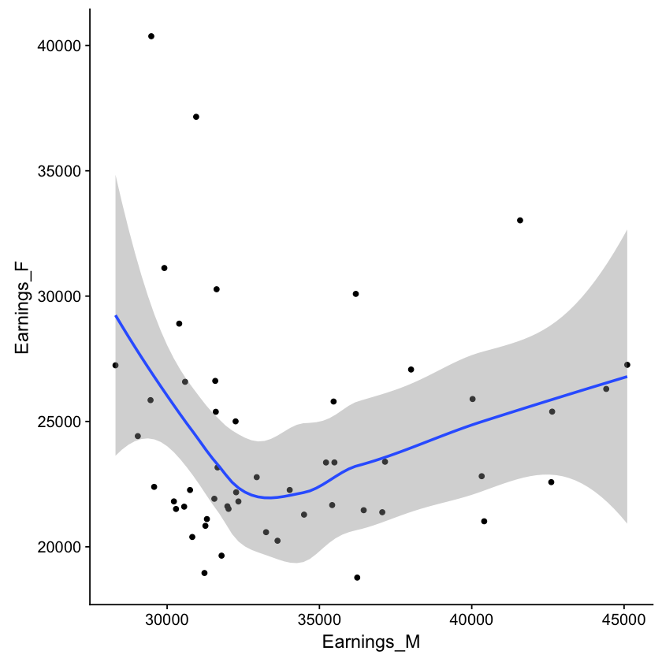

```r
ggplot(data = HDI, mapping = aes(x = Earnings_M, y = Earnings_F)) +
  geom_point() +
    geom_smooth()
```

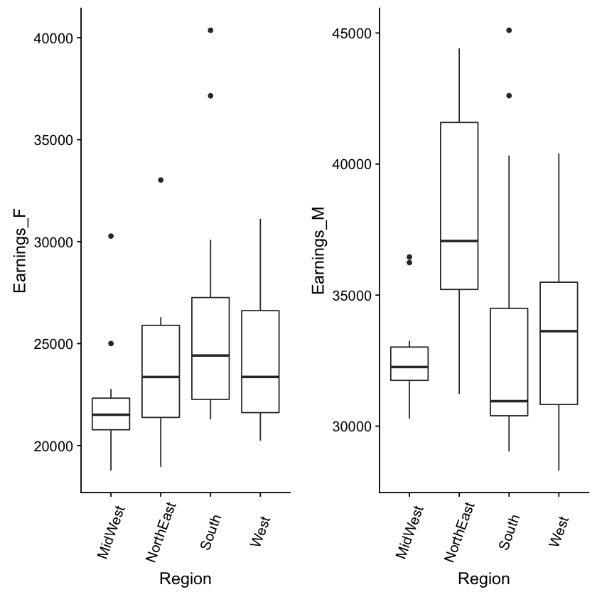

```r
b2  <- ggplot(HDI) +
  geom_boxplot(mapping = aes(x = Region, y = Earnings_M )) +
    theme(axis.text.x = element_text(angle=70, vjust=0.5))

plot_grid(b1, b2)
```

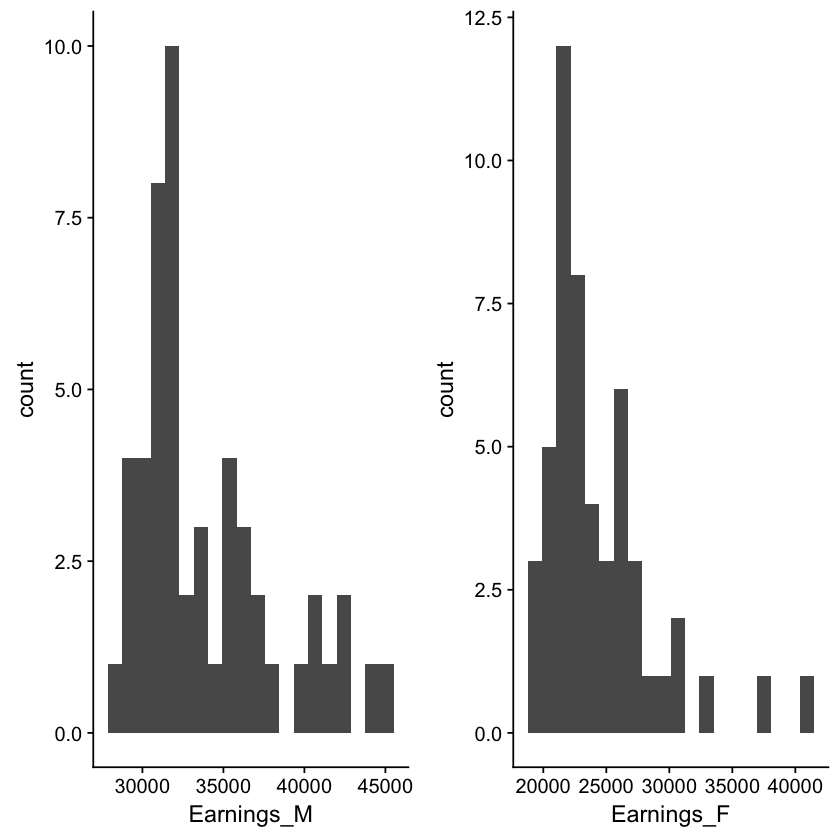

```r
plot_grid(h1, h2)
```

```r
summary(lm(Earnings_M ~ Earnings_F, data=HDI))
```

```
Call:
lm(formula = Earnings_M ~ Earnings_F, data = HDI)

Residuals:
   Min     1Q Median     3Q    Max
 -5679  -3097  -1732   2238  11120

Coefficients:
             Estimate Std. Error t value Pr(>|t|)
(Intercept) 3.394e+04  3.460e+03   9.809 3.81e-13 ***
Earnings_F  1.629e-03  1.402e-01   0.012    0.991
---
Signif. codes:  0 ‘***’ 0.001 ‘**’ 0.01 ‘*’ 0.05 ‘.’ 0.1 ‘ ’ 1

Residual standard error: 4329 on 49 degrees of freedom
Multiple R-squared:  2.755e-06,	Adjusted R-squared:  -0.02041
F-statistic: 0.000135 on 1 and 49 DF,  p-value: 0.9908
```

# Second pair

The second pair of data is the annual cost of public schools and the annual cost for private schools. The data could be collected from school surveys, educational organization and social survey. This pair of data is important because education is an essential part of the growth of society and it is important for people to understand better if everyone has the same opportunity. This pair of data allows us to see the difference of cost between public schools and private schools. Private schools cost more than public schools, however, in one of the sources we found from Washington Post, the author discusses whether private schools give better education than public schools. He questioned the difference and showed evidence that sometimes public schools students outperform the students from private schools.

# Hypothesis

We assume that private school cost more than that of public schools. We also think that on the graph, it’s going to show that the cost for public and private schools increase over time because the tuition for both type should be increasing every year.

```
Warning message:
“Removed 2 rows containing non-finite values (stat_smooth).”Warning message:
“Removed 2 rows containing missing values (geom_point).”
```

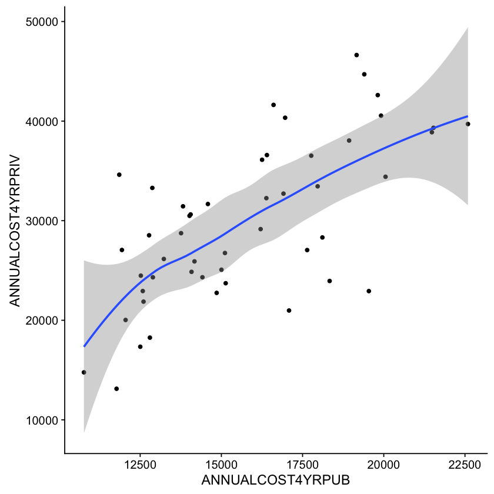

```r
ggplot(data = HDI, mapping = aes(x = ANNUALCOST4YRPUB, y = ANNUALCOST4YRPRIV)) +
  geom_point() +
    geom_smooth()
```

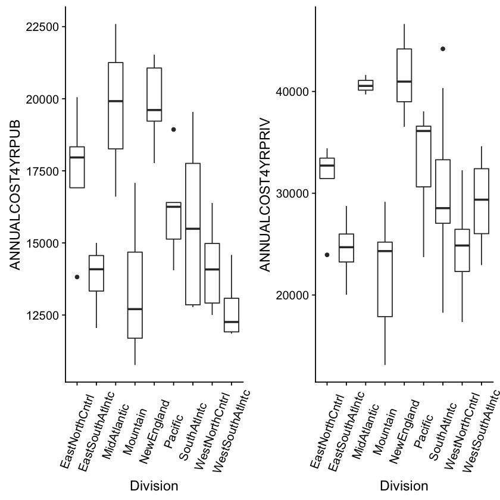

```r
plot_grid(b1, b2)
```

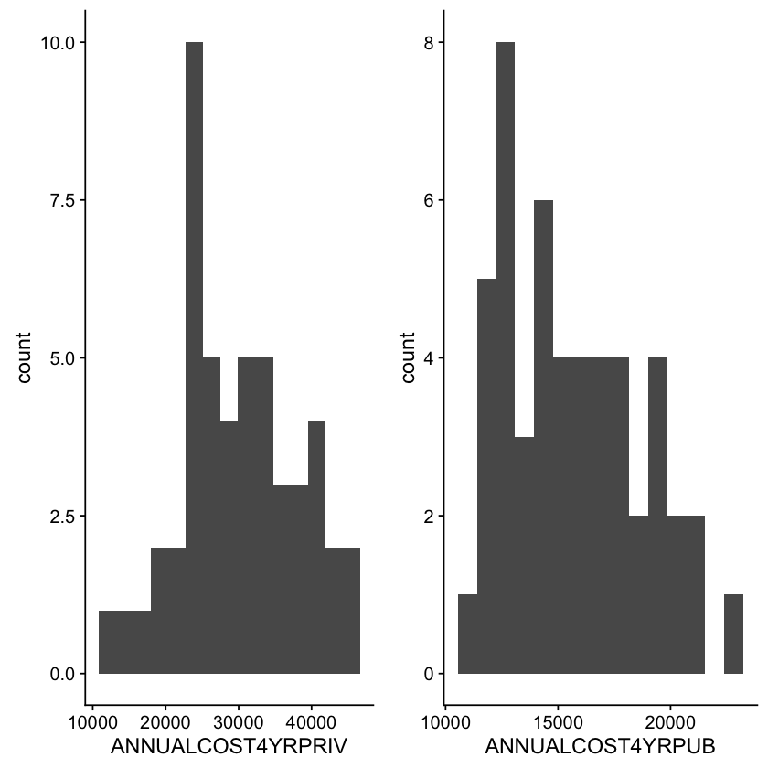

```r
h2  <- ggplot(data = HDI) +
  geom_histogram(mapping = aes(x = ANNUALCOST4YRPUB), bins = 15)

plot_grid(h1, h2)
```

```r
summary(lm(ANNUALCOST4YRPUB ~ ANNUALCOST4YRPRIV, data=HDI))
```

```
Call:
lm(formula = ANNUALCOST4YRPUB ~ ANNUALCOST4YRPRIV, data = HDI)

Residuals:
    Min      1Q  Median      3Q     Max
-5125.3 -1493.0   -26.6   960.2  5571.8

Coefficients:
                   Estimate Std. Error t value Pr(>|t|)
(Intercept)       8.060e+03  1.249e+03   6.456 5.48e-08 ***
ANNUALCOST4YRPRIV 2.577e-01  4.051e-02   6.361 7.63e-08 ***
---
Signif. codes:  0 ‘***’ 0.001 ‘**’ 0.01 ‘*’ 0.05 ‘.’ 0.1 ‘ ’ 1

Residual standard error: 2232 on 47 degrees of freedom
  (2 observations deleted due to missingness)
Multiple R-squared:  0.4626,	Adjusted R-squared:  0.4512
F-statistic: 40.46 on 1 and 47 DF,  p-value: 7.63e-08
```

# Third Pair

The third pair of data we picked is suicide rate and rape rate. The data could be collected from social surveys, statistic from the police office, record from suicide helping center and hospital. This is important because it show the relationship between rape and suicide, it show wether the trauma can cause a deadly consequence. In one of the sources we got, a girl who was raped committed suicide because of the torment she had to go through while confronting her attacker. It shows that the traumatic experience can learn to very bad consequence.

# Hypothesis

We assume that the higher the rape rate, the higher the suicide rate.

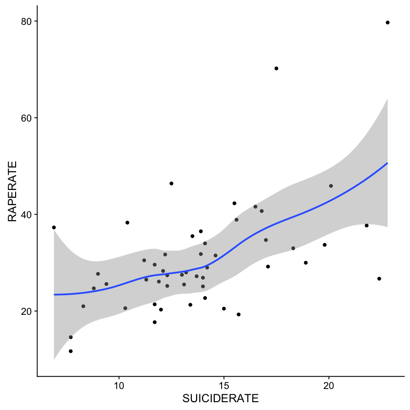

```r
ggplot(data = HDI, mapping = aes(x = SUICIDERATE, y = RAPERATE)) +
  geom_point() +
    geom_smooth()
```

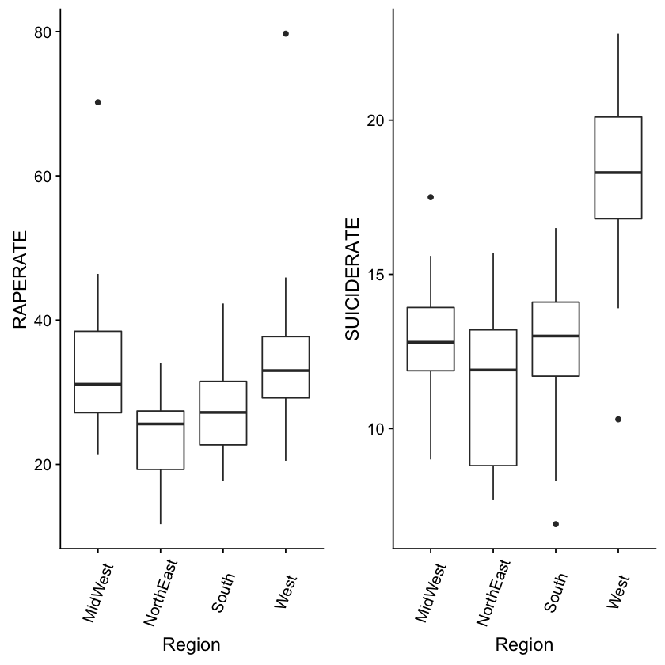

```r
plot_grid(b1, b2)
```

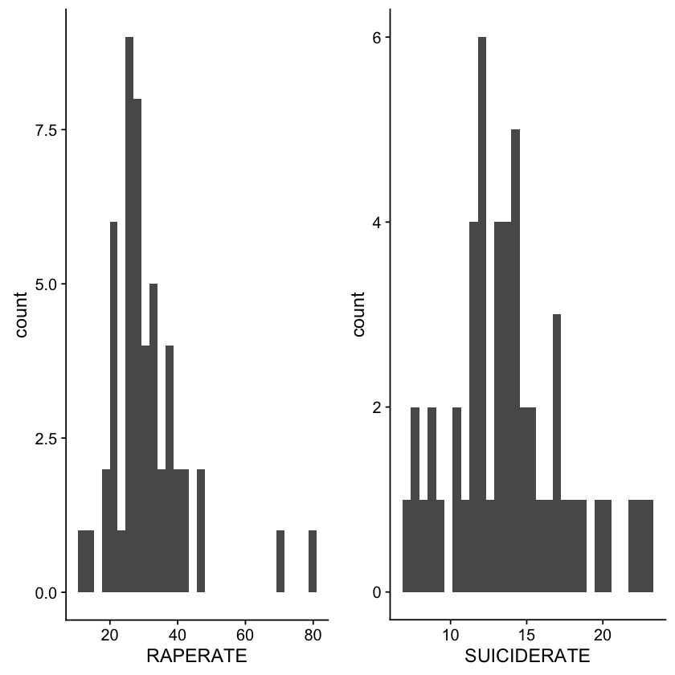

```r
plot_grid(h1, h2)
```

```r
summary(lm(SUICIDERATE ~ RAPERATE, data=HDI))
```

```
Call:
lm(formula = SUICIDERATE ~ RAPERATE, data = HDI)

Residuals:
    Min      1Q  Median      3Q     Max
-8.0017 -1.7574 -0.1161  1.2023  9.3055

Coefficients:
            Estimate Std. Error t value Pr(>|t|)
(Intercept)   8.5422     1.2574   6.793 1.39e-08 ***
RAPERATE      0.1705     0.0380   4.487 4.37e-05 ***
---
Signif. codes:  0 ‘***’ 0.001 ‘**’ 0.01 ‘*’ 0.05 ‘.’ 0.1 ‘ ’ 1

Residual standard error: 3.169 on 49 degrees of freedom
Multiple R-squared:  0.2912,	Adjusted R-squared:  0.2768
F-statistic: 20.13 on 1 and 49 DF,  p-value: 4.375e-05
```

# Fourth Variable

The fourth pair of data is labor force and GDP_PC. The data could be collected from companies that required labor force, and yearly report of the economic growth. This is important because it shows how labor force and GDP affect each other and the relationship between them. It can help us understand if labor force is benefitting or impeding the growth of GDP. From the website “world-watch”, we found proof that labor force helps the growth of GDP and economic expansion.